# Homework 7

your-name-here

## Problem 1: The infamous mule kick data 20pts

The file `mule_kicks.csv`, available for download (here)[https://kdlevin-uwstat.github.io/STAT340-Fall2021/hw/03/mule_kicks.csv], contains a simplified version of a very famous data set. The data consists of the number of soldiers killed by being kicked by mules or horses each year in a number of different companies in the Prussian army near the end of the 19th century.

This may seem at first to be a very silly thing to collect data about, but it is a very interesting thing to look at if you are interested in rare events. Deaths by horse kick were rare events that occurred independently of one another, and thus it is precisely the kind of process that we might expect to obey a Poisson distribution.

Download the data and read it into R by running

```r
download.file('https://kdlevin-uwstat.github.io/STAT340-Fall2021/hw/03/mule_kicks.csv', destfile='mule_kicks.csv')
mule_kicks = read.csv('mule_kicks.csv', header=TRUE)

head(mule_kicks)
```

```
##   deaths
## 1      0
## 2      0
## 3      0
## 4      0
## 5      0
## 6      0
```

`mule_kicks` contains a single column, called `deaths`. Each entry is the number of soldiers killed in one corps of the Prussian army in one year. There are 14 corps in the data set, studied over 20 years, for a total of 280 death counts.

### Part a: estimating the Poisson rate 5pts

Assuming that the mule kicks data follows a Poisson distribution, produce a point estimate for the rate parameter $\lambda$. There are no strictly right or wrong answers, here, though there are certainly better or worse ones.

```r
lambdahat <- mean(mule_kicks$deaths)
```

### Part b: constructing a CI 10pts

Using everything you know (Monte Carlo, CLT, etc.), construct a confidence interval for the rate parameter $\lambda$. Explain in reasonable detail what you are doing and why you are constructing the confidence interval in this way (a few sentences is fine!).

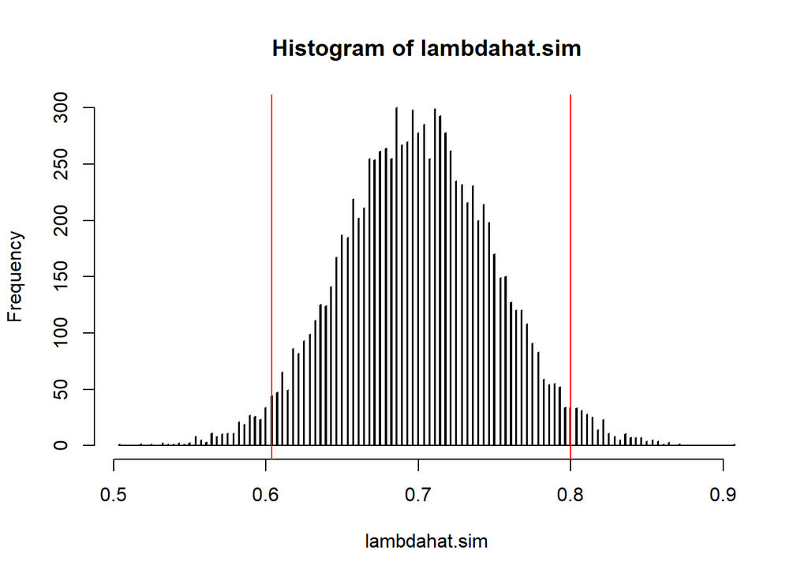

```r
NMC <- 10000
n <- length(mule_kicks$deaths)
lambdahat.sim <- replicate(NMC, mean(rpois(n, lambdahat)))
CI <- quantile(lambdahat.sim, c(0.025, 0.975))
hist(lambdahat.sim, breaks=1000)
abline(v=CI, col="red")
```

```r
CI
```

```
##      2.5%     97.5%
## 0.6035714 0.8000000
```

We used $\hat{\lambda}$ as our point estimate for $\lambda$. Then we generated 10000 samples of “fake data” - each of the same sample size from the initial data. These represent a simulated distribution of $\hat{\lambda}$. From here we take the 2.5th and 97.5th percentiles as cutoffs for our confidence interval.

The 95% confidence interval calculated is (0.6035714,0.8). ***

### Part c: assessing a model 5pts

Here’s a slightly more open-ended question. We *assumed* that the data followed a Poisson distribution. This may or may not be a reasonable assumption. Use any and all tools that you know to assess (either with code or simply in words) how reasonable or unreasonable this assumption is.

Once again, there are no strictly right or wrong answers here. Explain and defend your decisions and thought processes in a reasonable way and you will receive full credit.

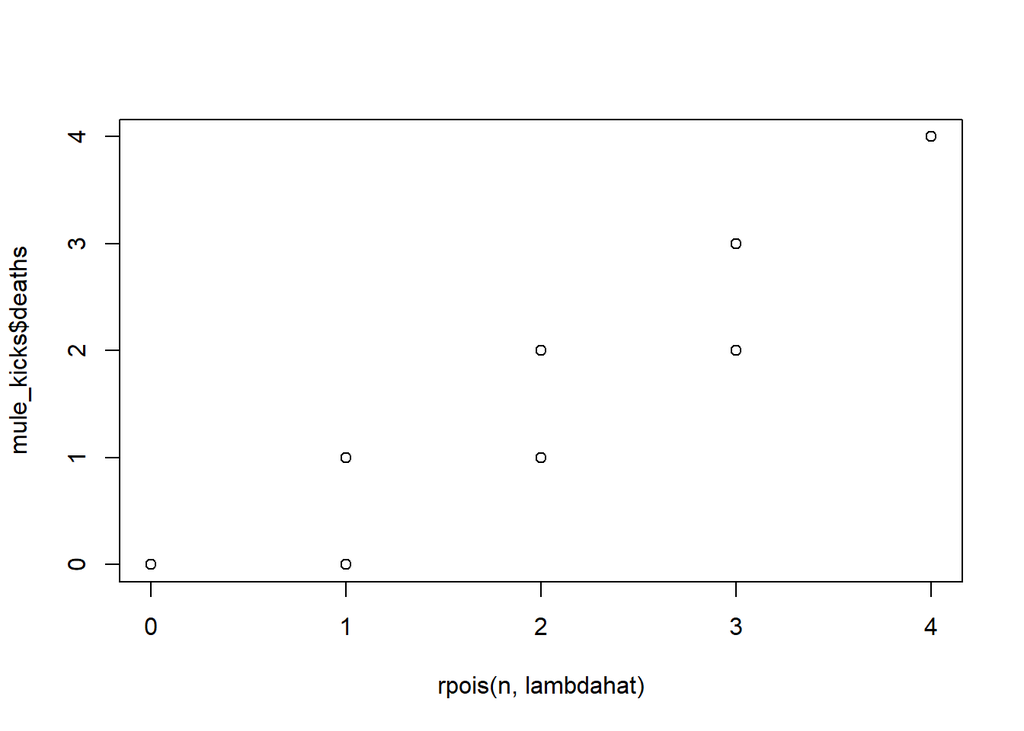

```r
qqplot(x = rpois(n, lambdahat), y = mule_kicks$deaths)
```

The qq plot of the true data and some randomly generated Poisson data looks extremely diagonal.

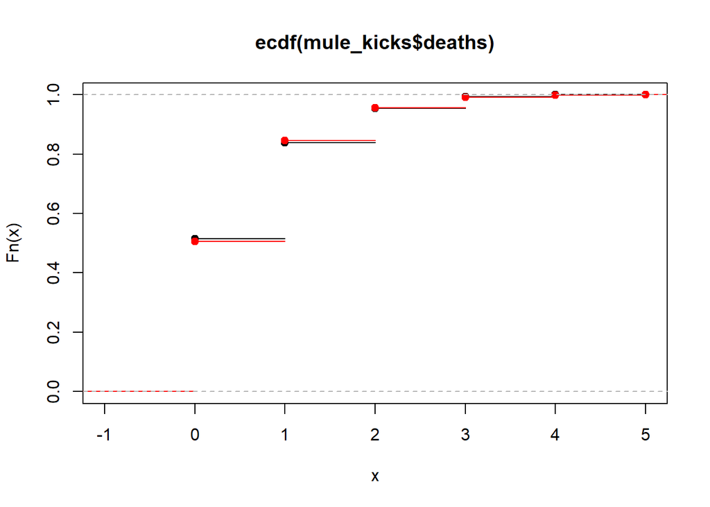

```r
plot(ecdf(mule_kicks$deaths))
plot(ecdf(rpois(1000, lambdahat)), add=TRUE, col="red")
```

If we plot the empirical CDF of the data against a CDF from a Poisson distribution we also see an extremely close relationship.

## Problem 2: Closing the loop 10 pts

In our discussion of the Universal Widgets of Madison company from lecture, we said that we were interested in two questions:

1. Estimating the probability $p$ that a widget is functional.
2. How many widgets should be in a batch to ensure that (with high probability) a batch ships with at least $5$ functional widgets in it?

We discussed question (1) at length in lecture. What about question (2)? Our client wants to know how many widgets should ship in each batch so as to ensure that the probability there are at least $5$ functional widgets in a batch is at least $0.99$.

Now, suppose that we have observed data and estimated $p$ to be $0.82$.

Use everything you know so far in this course to give a recommendation to the client. Be sure to explain clearly what you are doing and why. If there are any steps, assumptions, etc., that you are not 100% pleased with, feel free to point them out.

**Note:** there are at least two “obvious” ways to solve this problem. One is based on using Monte Carlo (i.e., assume $p=0.82$ is the truth, and try generating batches of different sizes, etc.). The other uses direct computation of probabilities, using basic facts about Binomial RVs. Neither of these is necessarily better than the other, and you do not need to use both approaches to receive full credit. Indeed, you are free to try doing something else entirely, if you wish. Just explain clearly what you are doing and why!

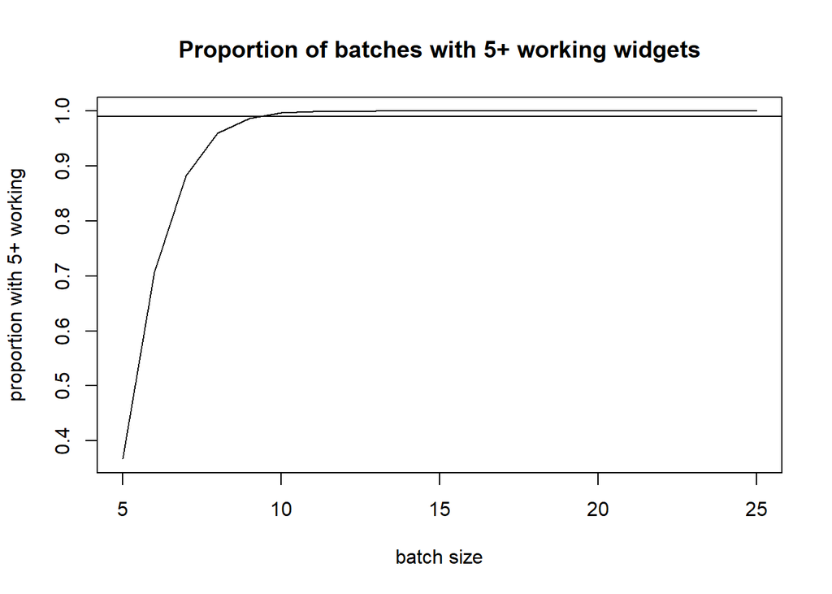

```r
p <- 0.82
ns <- 5:25
p5 <- 0
NMC <- 10000
for(i in 1:length(ns)){
  n <- ns[i]
  batches <- rbinom(NMC, size=n, prob=p)
  p5[i] <- mean(batches >= 5)
}
plot(x=ns, y=p5, type="l", main="Proportion of batches with 5+ working widgets", xlab="batch size", ylab="proportion with 5+ working")
abline(h=.99)
```

```r
(N <- ns[min(which(p5>.99))])
```

```
## [1] 10
```

```r
Nq <- 4
repeat{
  Nq <- Nq+1
  if(qbinom(.01,Nq, .82) >=5) break;
}
```

From simulation it seems that a batch size of 10 would have a 99% probability of having at least 5 working widgets.

If we were to use the binomial distribution to calculate the lowest n such that there’s only a 1% chance of 4 or fewer working, a batch size of 10 would do the trick.